# Project: Investigate a Dataset - TMDb movie data

- Introduction
- Data Wrangling
- Exploratory Data Analysis
- Conclusions

## Introduction

### Dataset Description

```python
import pandas as pd
import numpy as np
import matplotlib.pyplot as plt
from sklearn.metrics import r2_score
from datetime import datetime

%matplotlib inline
```

```python
tmdb_df = pd.read_csv("Database_TMDb_movie_data/tmdb-movies.csv")
# we want to display all the columns, so we need to remove the default limit
pd.set_option('display.max_columns', None)
tmdb_df.head(1)
```

|  | id | imdb_id | popularity | budget | revenue | original_title | cast | homepage | director | tagline | keywords | overview | runtime | genres | production_companies | release_date | vote_count | vote_average | release_year | budget_adj | revenue_adj |
| --- | --- | --- | --- | --- | --- | --- | --- | --- | --- | --- | --- | --- | --- | --- | --- | --- | --- | --- | --- | --- | --- |
| 0 | 135397 | tt0369610 | 32.985763 | 150000000 | 1513528810 | Jurassic World | Chris Pratt\|Bryce Dallas Howard\|Irrfan Khan\|Vi... | http://www.jurassicworld.com/ | Colin Trevorrow | The park is open. | monster\|dna\|tyrannosaurus rex\|velociraptor\|island | Twenty-two years after the events of Jurassic ... | 124 | Action\|Adventure\|Science Fiction\|Thriller | Universal Studios\|Amblin Entertainment\|Legenda... | 6/9/15 | 5562 | 6.5 | 2015 | 1.379999e+08 | 1.392446e+09 |

We can notice some fields that will need to be split by "|" for interpretation

```python
# we will not need to see all the columns anymore, we can enable again the limit on the columns count display
pd.reset_option('display.max_columns')
```

```python
# shape of the dataframe, data types and null values
tmdb_df.info()
```

```
<class 'pandas.core.frame.DataFrame'>
RangeIndex: 10866 entries, 0 to 10865
Data columns (total 21 columns):
 #   Column                Non-Null Count  Dtype
---  ------                --------------  -----
 0   id                    10866 non-null  int64
 1   imdb_id               10856 non-null  object
 2   popularity            10866 non-null  float64
 3   budget                10866 non-null  int64
 4   revenue               10866 non-null  int64
 5   original_title        10866 non-null  object
 6   cast                  10790 non-null  object
 7   homepage              2936 non-null   object
 8   director              10822 non-null  object
 9   tagline               8042 non-null   object
 10  keywords              9373 non-null   object
 11  overview              10862 non-null  object
 12  runtime               10866 non-null  int64
 13  genres                10843 non-null  object
 14  production_companies  9836 non-null   object
 15  release_date          10866 non-null  object
 16  vote_count            10866 non-null  int64
 17  vote_average          10866 non-null  float64
 18  release_year          10866 non-null  int64
 19  budget_adj            10866 non-null  float64
 20  revenue_adj           10866 non-null  float64
dtypes: float64(4), int64(6), object(11)
memory usage: 1.7+ MB
```

Some columns have null values

**Conclusion on the dataset description**

This dataset contains information about more than 10,000 movies collected from The Movie Database (TMDb), including user ratings and revenue.

We can notice the following information about this dataset:

- A few columns have null values.
- Some string columns contains lists of values separated by |
- The last 2 columns are budget and revenue adjusted to inflation, which will enable comparison despite release date span.

Note: we do not have the units of the int/float columns, neither do we have the scale for popularity.

### Question(s) for Analysis

1. Which movies are most popular from year to year?
2. What kinds of properties are associated with movies that have high revenues?

## Data Wrangling

### General Properties

```python
# shape of the dataframe
tmdb_df.shape
```

```
(10866, 21)
```

```python
# shape of the dataframe, data types and null values
tmdb_df.info()
```

```
<class 'pandas.core.frame.DataFrame'>
RangeIndex: 10866 entries, 0 to 10865
Data columns (total 21 columns):
 #   Column                Non-Null Count  Dtype
---  ------                --------------  -----
 0   id                    10866 non-null  int64
 1   imdb_id               10856 non-null  object
 2   popularity            10866 non-null  float64
 3   budget                10866 non-null  int64
 4   revenue               10866 non-null  int64
 5   original_title        10866 non-null  object
 6   cast                  10790 non-null  object
 7   homepage              2936 non-null   object
 8   director              10822 non-null  object
 9   tagline               8042 non-null   object
 10  keywords              9373 non-null   object
 11  overview              10862 non-null  object
 12  runtime               10866 non-null  int64
 13  genres                10843 non-null  object
 14  production_companies  9836 non-null   object
 15  release_date          10866 non-null  object
 16  vote_count            10866 non-null  int64
 17  vote_average          10866 non-null  float64
 18  release_year          10866 non-null  int64
 19  budget_adj            10866 non-null  float64
 20  revenue_adj           10866 non-null  float64
dtypes: float64(4), int64(6), object(11)
memory usage: 1.7+ MB
```

We can see an id column that could probably be used as the index of the dataframe

Most data types make sense with the content of the cells except the release_date which is not stored as a date.

We can also notice that the budget and revenue are stored as int64 while the budget_adj and revenue_adj are stored as float64.

The size of the int and float could potentially be adjusted.

```python
# general statistics on the dataset
tmdb_df.describe()
```

|  | id | popularity | budget | revenue | runtime | vote_count | vote_average | release_year | budget_adj | revenue_adj |
| --- | --- | --- | --- | --- | --- | --- | --- | --- | --- | --- |
| count | 10866.000000 | 10866.000000 | 1.086600e+04 | 1.086600e+04 | 10866.000000 | 10866.000000 | 10866.000000 | 10866.000000 | 1.086600e+04 | 1.086600e+04 |
| mean | 66064.177434 | 0.646441 | 1.462570e+07 | 3.982332e+07 | 102.070863 | 217.389748 | 5.974922 | 2001.322658 | 1.755104e+07 | 5.136436e+07 |
| std | 92130.136561 | 1.000185 | 3.091321e+07 | 1.170035e+08 | 31.381405 | 575.619058 | 0.935142 | 12.812941 | 3.430616e+07 | 1.446325e+08 |
| min | 5.000000 | 0.000065 | 0.000000e+00 | 0.000000e+00 | 0.000000 | 10.000000 | 1.500000 | 1960.000000 | 0.000000e+00 | 0.000000e+00 |
| 25% | 10596.250000 | 0.207583 | 0.000000e+00 | 0.000000e+00 | 90.000000 | 17.000000 | 5.400000 | 1995.000000 | 0.000000e+00 | 0.000000e+00 |
| 50% | 20669.000000 | 0.383856 | 0.000000e+00 | 0.000000e+00 | 99.000000 | 38.000000 | 6.000000 | 2006.000000 | 0.000000e+00 | 0.000000e+00 |
| 75% | 75610.000000 | 0.713817 | 1.500000e+07 | 2.400000e+07 | 111.000000 | 145.750000 | 6.600000 | 2011.000000 | 2.085325e+07 | 3.369710e+07 |
| max | 417859.000000 | 32.985763 | 4.250000e+08 | 2.781506e+09 | 900.000000 | 9767.000000 | 9.200000 | 2015.000000 | 4.250000e+08 | 2.827124e+09 |

We can see that some values make no sense (budget=0, revenue=0, runtime=0, budget_adj=0, revenue_adj=0)

### Data Cleaning

#### Id column

Let's see if the id column can be used as the index of the dataframe

```python
# check uniqueness of values
tmdb_df['id'].nunique()
```

```
10865
```

The dataset has 10866 rows and the unique ids are 10865. We need to confirm if the id that is not unique is part of a duplicated row.

```python
tmdb_df.duplicated().sum()
```

```
1
```

Yes it is! Thus we can use the id as the index of the dataset after having deleted the duplicated row if the id has not na values

```python
tmdb_df['id'].isna().any()
```

```
False
```

```python
# setting id as the index and dropping duplicated row at the same time
tmdb_df = tmdb_df.drop_duplicates().set_index('id', drop=True).sort_index()
tmdb_df.head(2)
```

| id | imdb_id | popularity | budget | revenue | original_title | cast | homepage | director | tagline | keywords | overview | runtime | genres | production_companies | release_date | vote_count | vote_average | release_year | budget_adj | revenue_adj |
| --- | --- | --- | --- | --- | --- | --- | --- | --- | --- | --- | --- | --- | --- | --- | --- | --- | --- | --- | --- | --- |
| 5 | tt0113101 | 1.234890 | 4000000 | 4300000 | Four Rooms | Tim Roth\|Antonio Banderas\|Jennifer Beals\|Madon... | NaN | Allison Anders\|Alexandre Rockwell\|Robert Rodri... | Twelve outrageous guests. Four scandalous requ... | hotel\|new year's eve\|witch\|bet\|hotel room | It's Ted the Bellhop's first night on the job.... | 98 | Comedy | Miramax Films\|A Band Apart | 12/25/95 | 293 | 6.4 | 1995 | 5.723867e+06 | 6.153158e+06 |
| 6 | tt0107286 | 0.815631 | 0 | 12136938 | Judgment Night | Emilio Estevez\|Cuba Gooding Jr.\|Denis Leary\|Je... | NaN | Stephen Hopkins | Don't move. Don't whisper. Don't even breathe. | chicago\|drug dealer\|boxing match\|escape\|one night | While racing to a boxing match, Frank, Mike, J... | 110 | Action\|Thriller\|Crime | Largo Entertainment\|JVC Entertainment Networks | 10/15/93 | 36 | 6.4 | 1993 | 0.000000e+00 | 1.832034e+07 |

#### Data types

```python
# printing datatypes
tmdb_df.info()
```

```
<class 'pandas.core.frame.DataFrame'>
Int64Index: 10865 entries, 5 to 417859
Data columns (total 20 columns):
 #   Column                Non-Null Count  Dtype
---  ------                --------------  -----
 0   imdb_id               10855 non-null  object
 1   popularity            10865 non-null  float64
 2   budget                10865 non-null  int64
 3   revenue               10865 non-null  int64
 4   original_title        10865 non-null  object
 5   cast                  10789 non-null  object
 6   homepage              2936 non-null   object
 7   director              10821 non-null  object
 8   tagline               8041 non-null   object
 9   keywords              9372 non-null   object
 10  overview              10861 non-null  object
 11  runtime               10865 non-null  int64
 12  genres                10842 non-null  object
 13  production_companies  9835 non-null   object
 14  release_date          10865 non-null  object
 15  vote_count            10865 non-null  int64
 16  vote_average          10865 non-null  float64
 17  release_year          10865 non-null  int64
 18  budget_adj            10865 non-null  float64
 19  revenue_adj           10865 non-null  float64
dtypes: float64(4), int64(5), object(11)
memory usage: 1.7+ MB
```

```python
# setting release_date as a datetime
tmdb_df['release_date'] = tmdb_df['release_date'].astype('datetime64')
```

Out of curiosity let's see the span of the release dates

```python
tmdb_df['release_date'].min()
```

```
Timestamp('1976-02-08 00:00:00')
```

```python
tmdb_df['release_date'].max()
```

```
Timestamp('2075-12-25 00:00:00')
```

We are in 2026. Some dates are wrong

```python
tmdb_df[tmdb_df['release_date'] > datetime(2026,9,9)].shape
```

```
(644, 20)
```

644 release dates are in the future. it does not mean the other columns are wrong though. So we will not drop these rows for now but we'll have to do it if we need to work with the release dates for our analysis

```python
# checking the number of unique values in genres to see if it can be transformed to categorical
tmdb_df['genres'].nunique()
```

```
2039
```

There are too many unique values to be transformed as a category, probably due to the concatenation of different unique values with a |

Do budget_adj and revenue_adj contain real float values or are they integers?

```python
for col in np.array(['budget_adj','revenue_adj']):
    tmdb_df[col + '_int'] = tmdb_df[col].apply(lambda x:x.is_integer())
    if False in list(tmdb_df[col + '_int'].unique()):
        print(f'{col} cannot be converted to int')
    else:
        print(f'{col} can be converted to int')
    tmdb_df.drop(columns = [col + '_int'], inplace=True)
```

```
budget_adj cannot be converted to int
revenue_adj cannot be converted to int
```

```python
# general statistics on the dataset to see if we can store the int and flowt using less memory.
tmdb_df.describe()
```

|  | popularity | budget | revenue | runtime | vote_count | vote_average | release_year | budget_adj | revenue_adj |
| --- | --- | --- | --- | --- | --- | --- | --- | --- | --- |
| count | 10865.000000 | 1.086500e+04 | 1.086500e+04 | 10865.000000 | 10865.000000 | 10865.000000 | 10865.000000 | 1.086500e+04 | 1.086500e+04 |
| mean | 0.646446 | 1.462429e+07 | 3.982690e+07 | 102.071790 | 217.399632 | 5.975012 | 2001.321859 | 1.754989e+07 | 5.136900e+07 |
| std | 1.000231 | 3.091428e+07 | 1.170083e+08 | 31.382701 | 575.644627 | 0.935138 | 12.813260 | 3.430753e+07 | 1.446383e+08 |
| min | 0.000065 | 0.000000e+00 | 0.000000e+00 | 0.000000 | 10.000000 | 1.500000 | 1960.000000 | 0.000000e+00 | 0.000000e+00 |
| 25% | 0.207575 | 0.000000e+00 | 0.000000e+00 | 90.000000 | 17.000000 | 5.400000 | 1995.000000 | 0.000000e+00 | 0.000000e+00 |
| 50% | 0.383831 | 0.000000e+00 | 0.000000e+00 | 99.000000 | 38.000000 | 6.000000 | 2006.000000 | 0.000000e+00 | 0.000000e+00 |
| 75% | 0.713857 | 1.500000e+07 | 2.400000e+07 | 111.000000 | 146.000000 | 6.600000 | 2011.000000 | 2.085325e+07 | 3.370173e+07 |
| max | 32.985763 | 4.250000e+08 | 2.781506e+09 | 900.000000 | 9767.000000 | 9.200000 | 2015.000000 | 4.250000e+08 | 2.827124e+09 |

We notice that some budget and revenue are missing (value 0). However it would not mean anything to replace them. We'll drop them for our analysis when we want to compare budget and revenue to other columns

```python
# min and max of an int32
np.iinfo('int32')
```

```
iinfo(min=-2147483648, max=2147483647, dtype=int32)
```

```python
# min and max of an int16
np.iinfo('int16')
```

```
iinfo(min=-32768, max=32767, dtype=int16)
```

```python
columns_to_update = np.array(['budget', 'revenue'])

for col in columns_to_update:
    tmdb_df[col] = tmdb_df[col].astype('int32')
```

We also notice that runtime could be converted as int16 as it goes from 0 to 900

```python
tmdb_df['runtime'] = tmdb_df['runtime'].astype('int16')
```

```python
# min and max of an float16
np.finfo('float16')
```

```
finfo(resolution=0.001, min=-6.55040e+04, max=6.55040e+04, dtype=float16)
```

popularity and vote_average could be converted as float16

```python
columns_to_update = np.array(['popularity', 'vote_average'])

for col in columns_to_update:
    tmdb_df[col] = tmdb_df[col].astype('float16')
```

```python
# min and max of an float32
np.finfo('float32')
```

```
finfo(resolution=1e-06, min=-3.4028235e+38, max=3.4028235e+38, dtype=float32)
```

budget_adj and revenue_adj could be float32 instead of float64

```python
columns_to_update = np.array(['budget_adj', 'revenue_adj'])

for col in columns_to_update:
    tmdb_df[col] = tmdb_df[col].astype('float32')
```

```python
# printing datatypes to check updates
tmdb_df.info()
```

```
<class 'pandas.core.frame.DataFrame'>
Int64Index: 10865 entries, 5 to 417859
Data columns (total 20 columns):
 #   Column                Non-Null Count  Dtype
---  ------                --------------  -----
 0   imdb_id               10855 non-null  object
 1   popularity            10865 non-null  float16
 2   budget                10865 non-null  int32
 3   revenue               10865 non-null  int32
 4   original_title        10865 non-null  object
 5   cast                  10789 non-null  object
 6   homepage              2936 non-null   object
 7   director              10821 non-null  object
 8   tagline               8041 non-null   object
 9   keywords              9372 non-null   object
 10  overview              10861 non-null  object
 11  runtime               10865 non-null  int16
 12  genres                10842 non-null  object
 13  production_companies  9835 non-null   object
 14  release_date          10865 non-null  datetime64[ns]
 15  vote_count            10865 non-null  int64
 16  vote_average          10865 non-null  float16
 17  release_year          10865 non-null  int64
 18  budget_adj            10865 non-null  float32
 19  revenue_adj           10865 non-null  float32
dtypes: datetime64[ns](1), float16(2), float32(2), int16(1), int32(2), int64(2), object(10)
memory usage: 1.4+ MB
```

```python
# checking columns which values need to be splitted by |
tmdb_df.head(2)
```

| id | imdb_id | popularity | budget | revenue | original_title | cast | homepage | director | tagline | keywords | overview | runtime | genres | production_companies | release_date | vote_count | vote_average | release_year | budget_adj | revenue_adj |
| --- | --- | --- | --- | --- | --- | --- | --- | --- | --- | --- | --- | --- | --- | --- | --- | --- | --- | --- | --- | --- |
| 5 | tt0113101 | 1.235352 | 4000000 | 4300000 | Four Rooms | Tim Roth\|Antonio Banderas\|Jennifer Beals\|Madon... | NaN | Allison Anders\|Alexandre Rockwell\|Robert Rodri... | Twelve outrageous guests. Four scandalous requ... | hotel\|new year's eve\|witch\|bet\|hotel room | It's Ted the Bellhop's first night on the job.... | 98 | Comedy | Miramax Films\|A Band Apart | 1995-12-25 | 293 | 6.398438 | 1995 | 5723867.5 | 6153157.5 |
| 6 | tt0107286 | 0.815430 | 0 | 12136938 | Judgment Night | Emilio Estevez\|Cuba Gooding Jr.\|Denis Leary\|Je... | NaN | Stephen Hopkins | Don't move. Don't whisper. Don't even breathe. | chicago\|drug dealer\|boxing match\|escape\|one night | While racing to a boxing match, Frank, Mike, J... | 110 | Action\|Thriller\|Crime | Largo Entertainment\|JVC Entertainment Networks | 1993-10-15 | 36 | 6.398438 | 1993 | 0.0 | 18320344.0 |

cast, director, keywords, genres and production_companies contain list stored as strings. However splitting them might affect later statistics on the whole dataframe. Thus, we'll split them on the go depending on the analysis needed.

For now, let's just fill the string missing values with an empty string.

```python
for col in np.array(['cast', 'director', 'keywords', 'genres', 'production_companies', 'imdb_id', 'homepage', 'tagline', 'overview']):
    tmdb_df[col].fillna('', inplace=True)
tmdb_df.head(5)
```

| id | imdb_id | popularity | budget | revenue | original_title | cast | homepage | director | tagline | keywords | overview | runtime | genres | production_companies | release_date | vote_count | vote_average | release_year | budget_adj | revenue_adj |
| --- | --- | --- | --- | --- | --- | --- | --- | --- | --- | --- | --- | --- | --- | --- | --- | --- | --- | --- | --- | --- |
| 5 | tt0113101 | 1.235352 | 4000000 | 4300000 | Four Rooms | Tim Roth\|Antonio Banderas\|Jennifer Beals\|Madon... |  | Allison Anders\|Alexandre Rockwell\|Robert Rodri... | Twelve outrageous guests. Four scandalous requ... | hotel\|new year's eve\|witch\|bet\|hotel room | It's Ted the Bellhop's first night on the job.... | 98 | Comedy | Miramax Films\|A Band Apart | 1995-12-25 | 293 | 6.398438 | 1995 | 5723867.5 | 6.153158e+06 |
| 6 | tt0107286 | 0.815430 | 0 | 12136938 | Judgment Night | Emilio Estevez\|Cuba Gooding Jr.\|Denis Leary\|Je... |  | Stephen Hopkins | Don't move. Don't whisper. Don't even breathe. | chicago\|drug dealer\|boxing match\|escape\|one night | While racing to a boxing match, Frank, Mike, J... | 110 | Action\|Thriller\|Crime | Largo Entertainment\|JVC Entertainment Networks | 1993-10-15 | 36 | 6.398438 | 1993 | 0.0 | 1.832034e+07 |
| 11 | tt0076759 | 12.039062 | 11000000 | 775398007 | Star Wars | Mark Hamill\|Harrison Ford\|Carrie Fisher\|Peter ... | http://www.starwars.com/films/star-wars-episod... | George Lucas | A long time ago in a galaxy far, far away... | android\|galaxy\|hermit\|death star\|lightsaber | Princess Leia is captured and held hostage by ... | 121 | Adventure\|Action\|Science Fiction | Lucasfilm\|Twentieth Century Fox Film Corporation | 1977-03-20 | 4428 | 7.898438 | 1977 | 39575592.0 | 2.789712e+09 |
| 12 | tt0266543 | 3.441406 | 94000000 | 864625978 | Finding Nemo | Albert Brooks\|Ellen DeGeneres\|Alexander Gould\|... | http://movies.disney.com/finding-nemo | Andrew Stanton\|Lee Unkrich | There are 3.7 trillion fish in the ocean, they... | predator\|harbor\|animation\|seagull\|underwater | A tale which follows the comedic and eventful ... | 100 | Animation\|Family | Walt Disney Pictures\|Pixar Animation Studios\|D... | 2003-05-30 | 3692 | 7.398438 | 2003 | 111423152.0 | 1.024887e+09 |
| 13 | tt0109830 | 6.714844 | 55000000 | 677945399 | Forrest Gump | Tom Hanks\|Robin Wright\|Gary Sinise\|Mykelti Wil... |  | Robert Zemeckis | The world will never be the same, once you've ... | vietnam veteran\|hippie\|mentally disabled\|runni... | A man with a low IQ has accomplished great thi... | 142 | Comedy\|Drama\|Romance | Paramount Pictures | 1994-07-06 | 4856 | 8.101562 | 1994 | 80911136.0 | 9.973333e+08 |

```python
# check columns with missing values
tmdb_df.info()
```

```
<class 'pandas.core.frame.DataFrame'>
Int64Index: 10865 entries, 5 to 417859
Data columns (total 20 columns):
 #   Column                Non-Null Count  Dtype
---  ------                --------------  -----
 0   imdb_id               10865 non-null  object
 1   popularity            10865 non-null  float16
 2   budget                10865 non-null  int32
 3   revenue               10865 non-null  int32
 4   original_title        10865 non-null  object
 5   cast                  10865 non-null  object
 6   homepage              10865 non-null  object
 7   director              10865 non-null  object
 8   tagline               10865 non-null  object
 9   keywords              10865 non-null  object
 10  overview              10865 non-null  object
 11  runtime               10865 non-null  int16
 12  genres                10865 non-null  object
 13  production_companies  10865 non-null  object
 14  release_date          10865 non-null  datetime64[ns]
 15  vote_count            10865 non-null  int64
 16  vote_average          10865 non-null  float16
 17  release_year          10865 non-null  int64
 18  budget_adj            10865 non-null  float32
 19  revenue_adj           10865 non-null  float32
dtypes: datetime64[ns](1), float16(2), float32(2), int16(1), int32(2), int64(2), object(10)
memory usage: 1.4+ MB
```

All non null values

## Exploratory Data Analysis

### Functions used thoughout the analysis

```python
def explode_column(df, col_name):
    df_copy = df.copy()
    df_copy[col_name] = (
        df_copy[col_name]
        .astype(str)
        .str.replace(r"[\[\]']", "", regex=True)  # removes [, ], and '
        .str.split(r"\s*\|\s*")           # splits on pipes
    )
    exploded_df = df_copy.explode(col_name)
    exploded_df = exploded_df[~exploded_df[col_name].isin(np.array(['', 'nan', 'NaN', 'None']))]

    return exploded_df
```

```python
def generate_title_and_axes(title, x_axis, y_axis):
    plt.title(title)
    plt.xlabel(x_axis)
    plt.ylabel(y_axis)
```

```python
# define a function to plot a variable according the index of the grouped dataframe
def grouped_genres_line_graph(df, variable):
    for genre in df['genres'].unique():
        plt.plot(df[df['genres']==genre]['release_year'], df[df['genres']==genre][variable], label = genre)
        plt.legend(bbox_to_anchor=(1.05, 1), loc='upper left', borderaxespad=0.)
        plt.figsize=(15,15)
    generate_title_and_axes(variable + ' by release year and genre', "release year", variable)
    plt.show()
```

```python
def get_tier_from_cat(x, categories=None):
    if not categories:
        return 'Undetermined'
    elif len(categories) != 4:
        return "This function only support 4 categories"
    else:
        for i in np.arange(0,4):
            interval = categories[i]
            if x in interval:
                if i == 0:
                    return "Low"
                elif i==1:
                    return "Medium"
                elif i==2:
                    return "High"
                else:
                    return "Top"
```

```python
def calculate_r2(model, x, y):
    predict = np.poly1d(model)
    return r2_score(y, predict(x))
```

```python
def box_plot(df):
    df.plot(kind='box', rot=90)
    generate_title_and_axes('Features values distribution', 'features', 'values')
```

```python
def scatter_with_trend(df,x,y):
    plt.scatter(df[x], df[y])
    # Add trend
    model = np.polyfit(df[x].astype(np.float32), df[y].astype(np.float32), 1)
    plt.plot(df[x].astype(np.float32), model[0] * df[x].astype(np.float32) + model[1], color="red")
    generate_title_and_axes(f"{y} vs {x}", x, y)
    plt.show()
    return model
```

### Which movies are most popular from year to year?

**Is the popularity impacted by the genre of a movie?**

```python
# exploding genres values for analysis:
tmdb_df_genres = explode_column(tmdb_df, 'genres')
```

```python
# grouping the data by genre and release_year
grouped_tmdb_df_genres = tmdb_df_genres.groupby(['genres', 'release_year']).agg({'imdb_id': 'nunique', 'popularity': 'mean'}).reset_index().rename(columns={'imdb_id': 'count of unique movies'})
grouped_tmdb_df_genres.head()
```

|  | genres | release_year | count of unique movies | popularity |
| --- | --- | --- | --- | --- |
| 0 | Action | 1960 | 8 | 0.590683 |
| 1 | Action | 1961 | 7 | 0.365932 |
| 2 | Action | 1962 | 8 | 0.708801 |
| 3 | Action | 1963 | 4 | 0.951630 |
| 4 | Action | 1964 | 5 | 0.813208 |

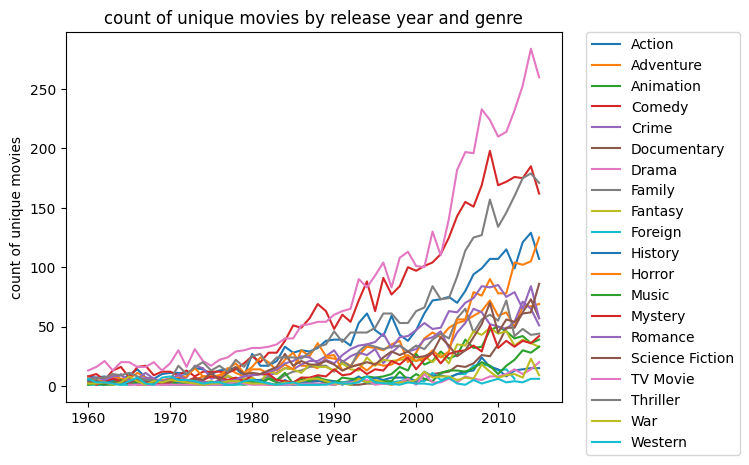

```python
# plotting the count of movies by year and genre
grouped_genres_line_graph(grouped_tmdb_df_genres, 'count of unique movies')
```

Drama is the genre of movies that is most released over time

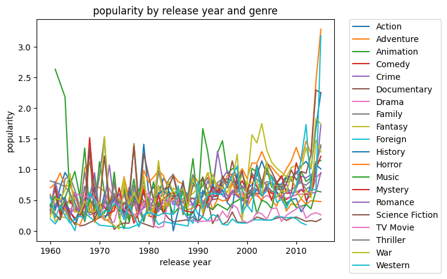

```python
# plotting the popularity of movies by year and genre
grouped_genres_line_graph(grouped_tmdb_df_genres, 'popularity')
```

The most popular genre varies over time. Recently it seems to be Adventure movies that are the most popular

**Do the production company and budget of a movie together have major impact on its popularity?**

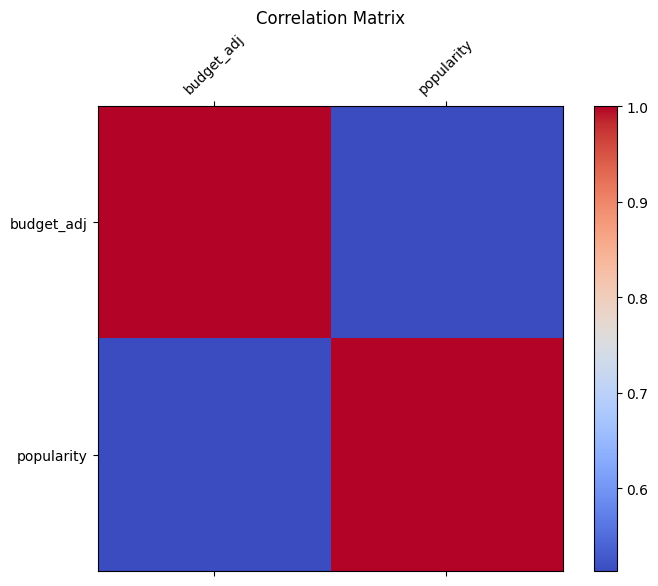

```python
corr = tmdb_df[["budget_adj", "popularity"]].corr()
plt.figure(figsize=(8, 6))
plt.matshow(corr, fignum=1, cmap="coolwarm")
plt.xticks(range(len(corr.columns)), corr.columns, rotation=45)
plt.yticks(range(len(corr.columns)), corr.columns)
plt.colorbar()
generate_title_and_axes("Correlation Matrix", '', '')
plt.show()
```

Let's see how the budget varies.

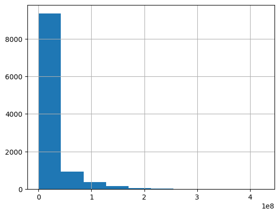

```python
tmdb_df['budget_adj'].hist()
```

Most of the budget adjusted are below 5e7. Let's categorize the budget ajusted values to analyze them.

Given the distribution of the budget, we'll use log bins

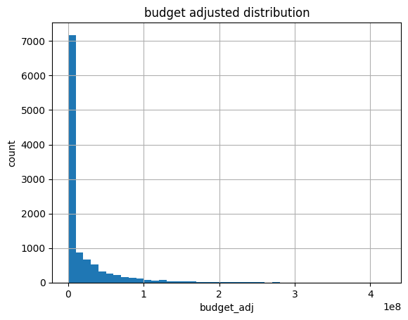

```python
tmdb_df['budget_adj'].hist(bins=np.arange(0,np.floor(tmdb_df['budget_adj'].max()), 1e7))
generate_title_and_axes('budget adjusted distribution', 'budget_adj', 'count')
```

Given the distribution of the values for budget_adj, we'll use a logspace for the bins of our categories

```python
min_val = tmdb_df["budget_adj"].replace(0, np.nan).min()  # Ignore 0s for log
max_val = tmdb_df["budget_adj"].max()
bins = np.logspace(np.log10(min_val), np.log10(max_val), num=5)
bins[0] = 0  # Include 0 in the first bin

tmdb_df["budget_adj_cat"] = pd.cut(tmdb_df["budget_adj"], bins=bins, include_lowest=True)
tmdb_df[['budget_adj', 'budget_adj_cat']].head()
```

| id | budget_adj | budget_adj_cat |
| --- | --- | --- |
| 5 | 5723867.5 | (2899797.447, 425000419.301] |
| 6 | 0.0 | (-0.001, 134.997] |
| 11 | 39575592.0 | (2899797.447, 425000419.301] |
| 12 | 111423152.0 | (2899797.447, 425000419.301] |
| 13 | 80911136.0 | (2899797.447, 425000419.301] |

Let's print the scatter plot to verify if we can see any links between budget_adj and popularity

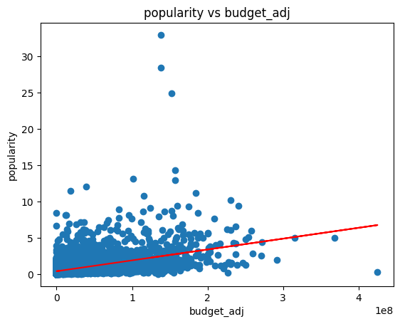

```python
model = scatter_with_trend(tmdb_df, 'budget_adj', 'popularity')
```

```python
# we need to convert data to float32 to avoid an overflow when calculating r2
calculate_r2(model, tmdb_df["budget_adj"].astype('float32'), tmdb_df["popularity"].astype('float32'))
```

```
0.2637244627516411
```

$R^{2}$ is really low, the regression is not a good fit to predict the popularity based on the budget

**Is the impact of the budget different from one production company to another?**

We first need to explode the production companies

```python
# exploding production companies values for analysis:
tmdb_df_companies = explode_column(tmdb_df, 'production_companies')
```

```python
tmdb_df_companies["production_companies"].nunique()
```

```
7879
```

The number of production companies being high, we'll create a function to be able to run it on different subset of the companies.

```python
def popularity_analysis(companies, filtered_df):

    # calculate mean popularity by production company, budget adjusted category and genre
    groups = (
        filtered_df.groupby(
            ["production_companies", "budget_adj_cat", "genres"], observed=False
        )["popularity"]
        .mean()
        .unstack(level="genres")
    )

    # define subplots
    height = len(companies) * 16
    fig, axes = plt.subplots(
        nrows=int(np.ceil(len(companies)/2, np.empty(1,dtype=np.float64))[0]),
        ncols=2,
        figsize=(16, height),
        sharey=True,
        constrained_layout=True,
    )

    flat_axes = axes.ravel()

    for ax, company in zip(flat_axes, companies):
        if company in groups.index.get_level_values(0):
            data_slice = groups.loc[company]
            sub_fig = data_slice.plot(kind="bar", ax=ax, width=0.8, rot=90, legend=False, figsize=(8, 16))
            sub_fig.set_xlabel('')
            sub_fig.set_ylabel('')
            sub_fig.set_title(company)

    # add legend at bottom of the whole figure
    handles, labels = flat_axes[0].get_legend_handles_labels()
    fig.legend(
        handles,
        labels,
        title="Genres",
        loc="lower center",
        bbox_to_anchor=(0.5, -0.15),
        ncols=5,
        frameon=True,
    )
    fig.supxlabel('Budget adjusted category')
    fig.supylabel('Mean Popularity')
    fig.suptitle(
        "Popularity by Budget adjusted category, Genre, and Production Company", fontsize=14
    )
    plt.show()
```

There are way too many production compagnies to plot a graph for each of them. We'll focus on top companies first.

```python
# keep only top companies to lighten the graphs
prod_comp_released_counts = tmdb_df_companies[(tmdb_df_companies["production_companies"] != 'nan') & (tmdb_df_companies["budget_adj"] > 0)]["production_companies"].value_counts()

top_companies = prod_comp_released_counts.head(6).index.tolist()
filtered_df = tmdb_df_companies[tmdb_df_companies["production_companies"].isin(top_companies)].copy()
```

```python
# we want a plot colored by genre, so we need to explode the column
filtered_df_genres = explode_column(filtered_df, 'genres')
```

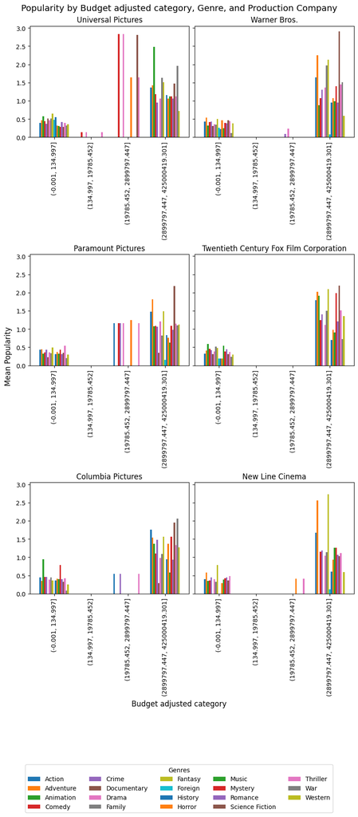

```python
popularity_analysis(top_companies, filtered_df_genres)
```

Top production companies seem to generally have a better popularity when the budget is higher.

Though, they seem to be the ones with high budget too. Let's see the bottom companies

```python
# keep only bottom companies to lighten the graphs
bottom_companies = prod_comp_released_counts.tail(6).index.tolist()
filtered_df = tmdb_df_companies[tmdb_df_companies["production_companies"].isin(bottom_companies)].copy()
```

```python
# we want a plot colored by genre, so we need to explode the column
filtered_df_genres = explode_column(filtered_df, 'genres')
```

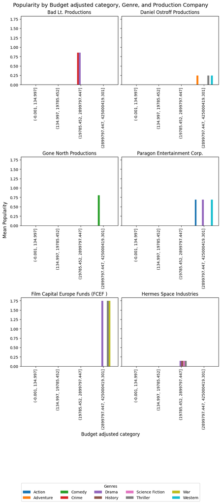

```python
popularity_analysis(bottom_companies, filtered_df_genres)
```

The bottom production companies do not release enough movies to be interpretable.

Let's set a minimum and a maximum of movies released by the company.

```python
prod_comp_released_counts = prod_comp_released_counts.reset_index()
```

```python
medium_companies = prod_comp_released_counts[(prod_comp_released_counts['production_companies']>150) & (prod_comp_released_counts['production_companies']<250)].tail(6)['index'].tolist()
filtered_df = tmdb_df_companies[tmdb_df_companies["production_companies"].isin(medium_companies)].copy()
```

```python
# we want a plot colored by genre, so we need to explode the column
filtered_df_genres = explode_column(filtered_df, 'genres')
```

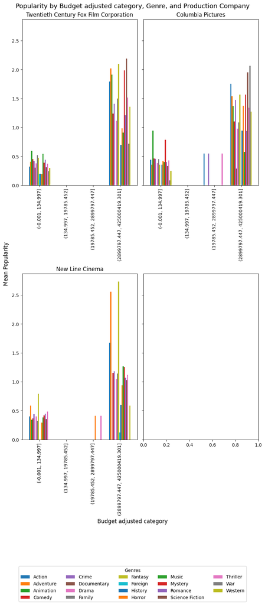

```python
popularity_analysis(medium_companies, filtered_df_genres)
```

Once again, the budget is mostly on the high side for successful movies

It seems that inside a company the budget impact the popularity but the popularity is more impacted by the production company rather than the budget

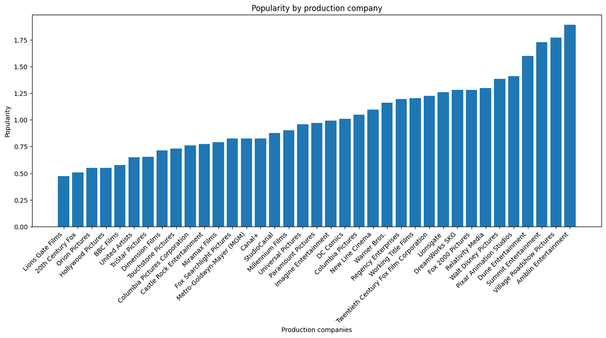

```python
grouped_companies = tmdb_df_companies.groupby("production_companies").agg({'imdb_id': 'nunique', 'popularity': 'mean'}).reset_index().sort_values(by='popularity', ascending=True)
top_grouped_companies = grouped_companies[(grouped_companies['production_companies']!= 'nan') & (grouped_companies['imdb_id']>50)]
plt.figure(figsize=(16, 6))
plt.bar(top_grouped_companies['production_companies'], top_grouped_companies["popularity"])
plt.xticks(rotation=45, ha='right')
generate_title_and_axes('Popularity by production company', 'Production companies', 'Popularity')
plt.show()
```

This graph seems to confirm our suspicion: the production company has a clear impact on the popularity of a movie

### What kinds of properties are associated with movies that have high revenues?

What's the distribution of revenue?

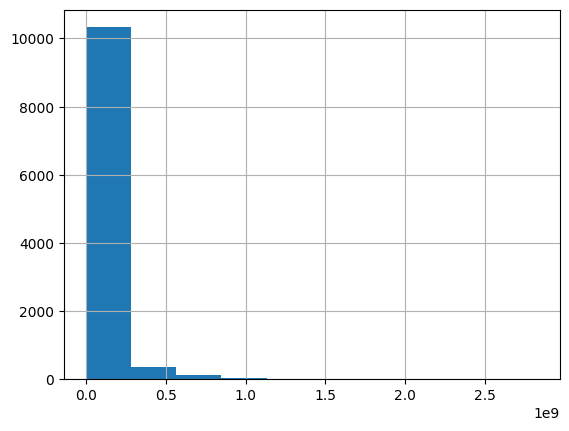

```python
tmdb_df['revenue_adj'].hist()
```

Most movies have a revenue adjusted below 5e8

```python
# we will use the revenue_adj column to have all the revenues comparable to each other with inflation considered
# some revenue_adj are 0, which makes no sense, let's remove them from the analysis
tmdb_df_revenue = tmdb_df[tmdb_df['revenue_adj']>0]
```

```python
# statistics on the movies with more than 0 as a revenue_adj
tmdb_df_revenue.describe()
```

|  | popularity | budget | revenue | runtime | vote_count | vote_average | release_year | budget_adj | revenue_adj |
| --- | --- | --- | --- | --- | --- | --- | --- | --- | --- |
| count | 4849.000000 | 4.849000e+03 | 4.849000e+03 | 4849.000000 | 4849.000000 | 4849.000000 | 4849.000000 | 4.849000e+03 | 4.849000e+03 |
| mean | 1.044922 | 2.956961e+07 | 8.835312e+07 | 107.968035 | 436.283151 | 6.152344 | 2000.919777 | 3.516208e+07 | 1.151009e+08 |
| std | 1.356445 | 4.051761e+07 | 1.590720e+08 | 21.113779 | 806.485754 | 0.798340 | 11.569650 | 4.376117e+07 | 1.988557e+08 |
| min | 0.001117 | 0.000000e+00 | -1.513461e+09 | 15.000000 | 10.000000 | 2.099609 | 1960.000000 | 0.000000e+00 | 2.370705e+00 |
| 25% | 0.387695 | 1.700000e+06 | 7.700000e+06 | 95.000000 | 46.000000 | 5.601562 | 1994.000000 | 2.329409e+06 | 1.046585e+07 |
| 50% | 0.680664 | 1.500000e+07 | 3.180000e+07 | 104.000000 | 147.000000 | 6.199219 | 2004.000000 | 2.032801e+07 | 4.395666e+07 |
| 75% | 1.210938 | 4.000000e+07 | 9.977568e+07 | 117.000000 | 435.000000 | 6.699219 | 2010.000000 | 4.973516e+07 | 1.316482e+08 |
| max | 33.000000 | 4.250000e+08 | 2.068178e+09 | 705.000000 | 9767.000000 | 8.398438 | 2015.000000 | 4.250000e+08 | 2.827124e+09 |

```python
# we want to focus on movies with high revenue, so we select revenue_adj above 75%
top_revenue_tmdb_df = tmdb_df_revenue[tmdb_df_revenue['revenue_adj'] >= tmdb_df_revenue['revenue_adj'].quantile(.75)]
```

```python
# statistics for movies with top revenues
top_revenue_tmdb_df.describe()
```

|  | popularity | budget | revenue | runtime | vote_count | vote_average | release_year | budget_adj | revenue_adj |
| --- | --- | --- | --- | --- | --- | --- | --- | --- | --- |
| count | 1213.000000 | 1.213000e+03 | 1.213000e+03 | 1213.000000 | 1213.000000 | 1213.000000 | 1213.000000 | 1213.0 | 1.213000e+03 |
| mean | 2.033203 | 6.609242e+07 | 2.683042e+08 | 116.445177 | 1126.307502 | 6.421875 | 1999.201154 | 77468816.0 | 3.525644e+08 |
| std | 2.167969 | 5.664778e+07 | 2.349501e+08 | 27.856830 | 1278.489641 | 0.715820 | 12.604773 | 56243864.0 | 2.813567e+08 |
| min | 0.017502 | 0.000000e+00 | -1.513461e+09 | 69.000000 | 10.000000 | 4.101562 | 1960.000000 | 0.0 | 1.316482e+08 |
| 25% | 0.938477 | 2.200000e+07 | 1.330000e+08 | 99.000000 | 287.000000 | 5.898438 | 1993.000000 | 34343204.0 | 1.772605e+08 |
| 50% | 1.480469 | 5.200000e+07 | 1.941687e+08 | 113.000000 | 654.000000 | 6.398438 | 2002.000000 | 67857864.0 | 2.535000e+08 |
| 75% | 2.416016 | 9.200000e+07 | 3.257566e+08 | 129.000000 | 1479.000000 | 6.898438 | 2009.000000 | 110399952.0 | 4.230204e+08 |
| max | 33.000000 | 3.800000e+08 | 2.068178e+09 | 705.000000 | 9767.000000 | 8.296875 | 2015.000000 | 368371264.0 | 2.827124e+09 |

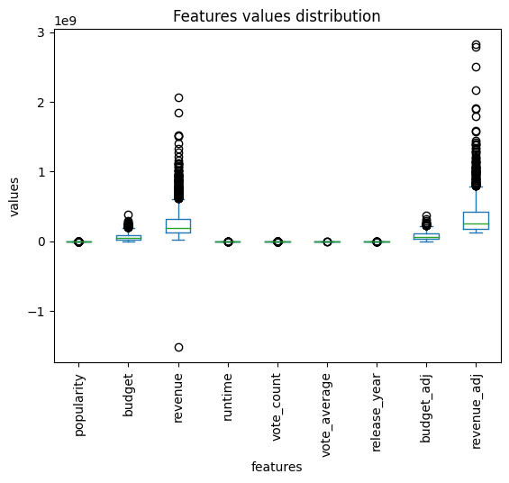

```python
# plot distribution of each variables for top revenue movies
box_plot(top_revenue_tmdb_df)
```

the scale being so different for revenue and budget, we cannot clearly see the other features. Let's split the graph by scale

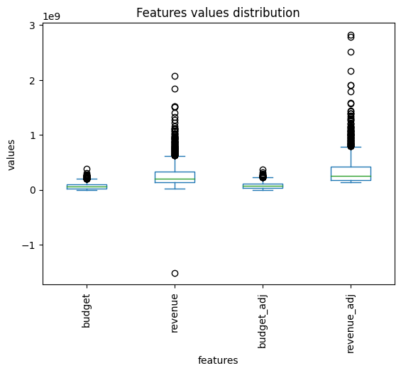

```python
box_plot(top_revenue_tmdb_df[['budget', 'revenue', 'budget_adj', 'revenue_adj']])
```

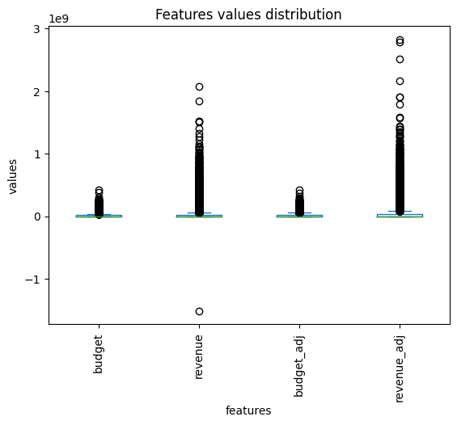

```python
box_plot(tmdb_df[['budget', 'revenue', 'budget_adj', 'revenue_adj']])
```

By comparing the 2 graphs, we can see that the budget is generally higher for movie with high revenues.

Let's see if we can find a mathematical relationship being both.

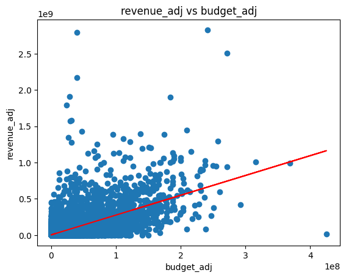

```python
model = scatter_with_trend(tmdb_df,'budget_adj','revenue_adj')
```

```python
calculate_r2(model, tmdb_df["budget_adj"], tmdb_df["revenue_adj"])
```

```
0.418125970343706
```

$R^{2}$ is low, which means the linear regression is not a good prediction for revenue based on budget.

Is it the same if we take only high revenue movies?

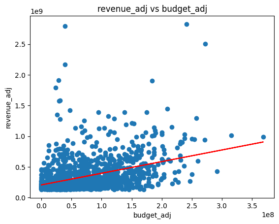

```python
model = scatter_with_trend(top_revenue_tmdb_df,'budget_adj','revenue_adj')
```

```python
calculate_r2(model, top_revenue_tmdb_df["budget_adj"], top_revenue_tmdb_df["revenue_adj"])
```

```
0.14406830141702054
```

We come to the same conclusion. $R^{2}$ is even lower

Would the vote_average be related to the revenue_adj?

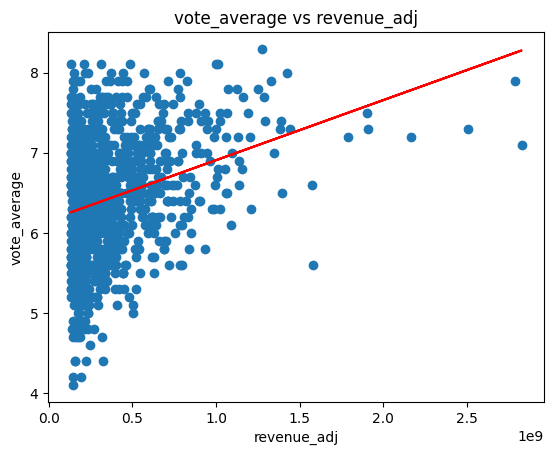

```python
model = scatter_with_trend(top_revenue_tmdb_df,'revenue_adj','vote_average')
```

```python
calculate_r2(model, top_revenue_tmdb_df["revenue_adj"].astype('float32'), top_revenue_tmdb_df["vote_average"].astype('float32'))
```

```
0.08693167431452875
```

$R^{2}$ is low again, which means the linear regression is not a good prediction for vote average based on revenue.

Let's do a more general analysis with a correlation matrix

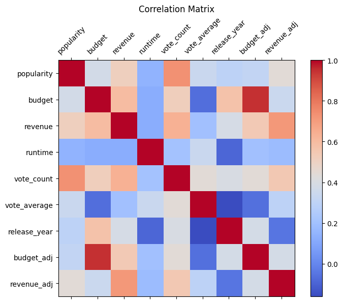

```python
corr = top_revenue_tmdb_df.corr(numeric_only = True)
plt.figure(figsize=(8, 6))
plt.matshow(corr, fignum=1, cmap="coolwarm")
plt.xticks(range(len(corr.columns)), corr.columns, rotation=45)
plt.yticks(range(len(corr.columns)), corr.columns)
plt.colorbar()
generate_title_and_axes("Correlation Matrix", '', '')
plt.show()
```

Except for revenue, the highest correlation with revenue_adj would be the vote_count and the popularity

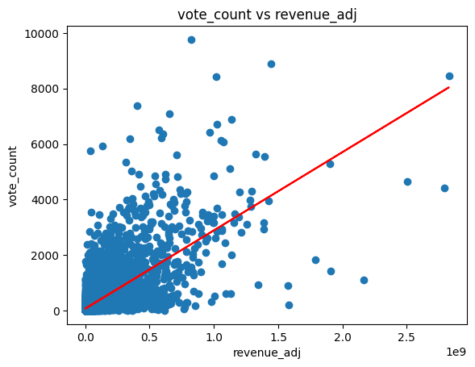

```python
model = scatter_with_trend(tmdb_df,'revenue_adj','vote_count')
```

```python
calculate_r2(model, tmdb_df["revenue_adj"].astype('float32'), tmdb_df["vote_count"].astype('float32'))
```

```
0.5011800053579202
```

$R^{2}$ is still low though, which tend to conclude it is not a linear relationship

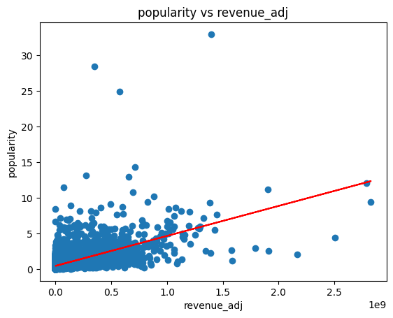

```python
model = scatter_with_trend(tmdb_df,'revenue_adj','popularity')
```

```python
calculate_r2(model, tmdb_df["revenue_adj"].astype('float32'), tmdb_df["popularity"].astype('float32'))
```

```
0.3709605483951688
```

Here also $R^{2}$ is low, which tend to conclude it is not linear relationship

## Conclusions

This dataset enabled us to better understand the preferences of the viewers and what makes a high revenue movie.

To have a high revenue, a movie seem to need a slightly higher budget in general. Though the relation between both is not linear. The revenue of a movie is also moderately linked to its popularity and the vote count.

To go deeper, we could verify if the production company of a movie has an impact on the revenue more than the budget. Is the release month of any importance too?

## Limitations

The analysis relies on descriptive statistics and linear regression to show relationships without establishing causality or controlling for confounding variables like marketing expenditure, release timing, or star power.

## Submitting your Project

```python
# Running this cell will execute a bash command to convert this notebook to an .html file
!python -m nbconvert --to html Investigate_a_Dataset.ipynb
```

```
[NbConvertApp] Converting notebook Investigate_a_Dataset.ipynb to html
[NbConvertApp] WARNING | Alternative text is missing on 20 image(s).
[NbConvertApp] Writing 1970252 bytes to Investigate_a_Dataset.html
```